# Linear Regression II - model bashing

## Textbook assumptions of linear regression

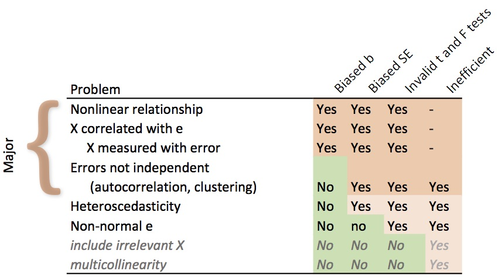

# 3. Graphical ways to assess model fit

*Model checking is a really important part of statistical analysis. It is also a pain.*

## Compare data to replications from the model

Gelman gives a number of examples of examining replicated data from a proposed model to see if it seems to fit the original data

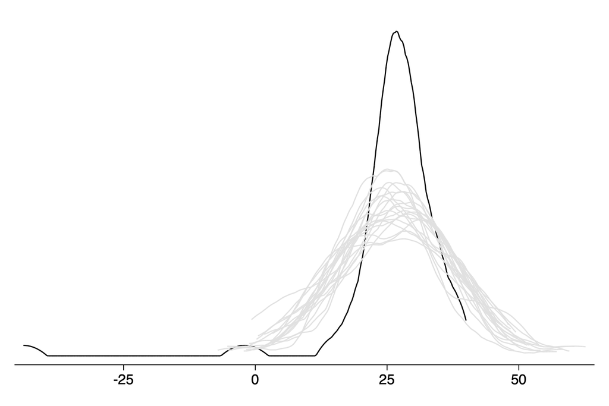

## Misspecification (functional form)

Where a regression omits the “correct” form of the relationship between predictors and outcome.

Example:

$$y_i=\beta_0 + \beta_1x_i + \beta_2z_i + \epsilon_i$$

vs. true relationship

$$y_i=\gamma_0 + \gamma_1x_i + \gamma_2x_i^2+\gamma_3z_i + \epsilon_i$$

## Visual checks

#### A misspecified model (with covariates x and z)

```stata
regress y2 x z
```

```
      Source |       SS           df       MS      Number of obs   =     1,000
-------------+----------------------------------   F(2, 997)       =   2823.40
       Model |  8303.67116         2  4151.83558   Prob > F        =    0.0000
    Residual |  1466.09724       997  1.47050877   R-squared       =    0.8499
-------------+----------------------------------   Adj R-squared   =    0.8496
       Total |   9769.7684       999  9.77954795   Root MSE        =    1.2126

------------------------------------------------------------------------------
          y2 | Coefficient  Std. err.      t    P>|t|     [95% conf. interval]
-------------+----------------------------------------------------------------
           x |   9.990111   .1329626    75.13   0.000     9.729193    10.25103
           z |  -.0657056   .1373252    -0.48   0.632    -.3351851    .2037739
       _cons |  -1.612517   .1025055   -15.73   0.000    -1.813668   -1.411366
------------------------------------------------------------------------------
```

## Visual checks

```stata
rvfplot, name(rvf2, replace)
rvpplot x, name(rvpx2, replace)
rvpplot z, name(rvpz2, replace)
```

[figure not shown]

## Other ways to look - scatter and binned scatter

```stata
scatter y2 x, name(scatter,replace)
binscatter y2 x, name(bin,replace)
```

[figure not shown]

## Quadratic forms

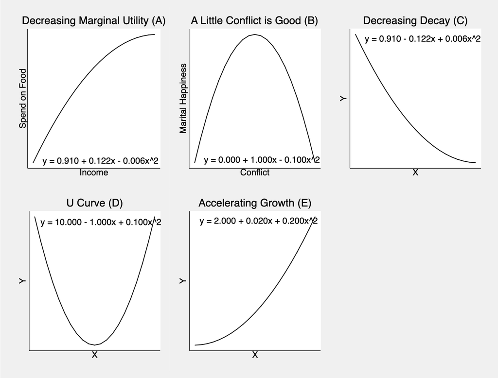

## Correct specification

```stata
regress y2 c.x##c.x z
```

[output not shown]

## Graph y as a function of quadratic form of x

```stata
qui margins ,at(x=(.01(.02)1))
qui marginsplot
```

[figure not shown]

# 4. Summary measures of model fit

*single-number summaries tell you much less about why a model fits poorly than graphing does*

## Variance explained

Model estimation provides a residual standard deviation ($\hat\sigma_{resid}$) that describes the residuals. As you know the total variation in the outcome variable, an intuitive measure is the R-squared:

$$R^2=1-(\hat\sigma_{resid}^2/s_y^2)$$

There are other summary statistics of model fit like AIC and BIC that penalize models with more parameters. All give much less information than graphing about why the model does not fit.

# External and cross-validation

External validation

One of the best forms of validation is to build a model in one dataset and then assess how well it fits a different dataset from another population to which you want to generalize the data.

Cross-validation

There is a procedure to try to capture the effect of external validation using a single dataset called Loo-CV or “leave out one” cross-validation.

- You leave out one observation, construct a model and use it to predict the missing observation and repeat for all observations in the data.
- Different metrics can be used to represent the average error of predicting the omitted observation.
- This addresses the overfitting problem of using the same data to estimate and evaluate the model.

# Robust regression

add the option `vce(robust)` or `vce(cluster cluster_id)`

```stata
regress y2 x z, vce(robust)
```

- relaxes the assumption of independent errors
  - for clustered errors include `vce(cluster cluster_id)` (implies robust as well)
- relaxes the assumption of homoscedasticity
- relaxes the assumption of normally distributed errors

You can use it as a type of diagnostic test: if there are no violations of these assumptions the s.e.’s of the coefficients will barely change with the option…and vice versa

# Missing data

To look at a series of nested models you should add the following to your regression.

```stata
local fullmodel "mpg, foreign, weight, rep78" // all the models in your full model
regress mpg foreign weight if !missing(`fullmodel')
```

What is the problem

1. When comparing models, you want to have the same data in each model (and particularly when comparing model fit statistics)
2. More generally missing data is a potentially much larger threat to your ability to project and make inferences about the sampled population. We will spend a whole class on this.

# An example of model checking

Go to tinyurl.com/ncsp-methods